# Find parameters for building urban communities

# Predict abundance from percentage of checklists present

Each species is recorded on checklists, within each city we have found the percentage of all checklists within a city that a species is recorded on. A city with a low number of total checklists is likely to have eratic and unreliable values for species percentage of checklists. Here we try to find out what is the minimum number of checklists for a city to have, for percentage of total checklists to map to abundance.

## Woodpigeon breeding abundance

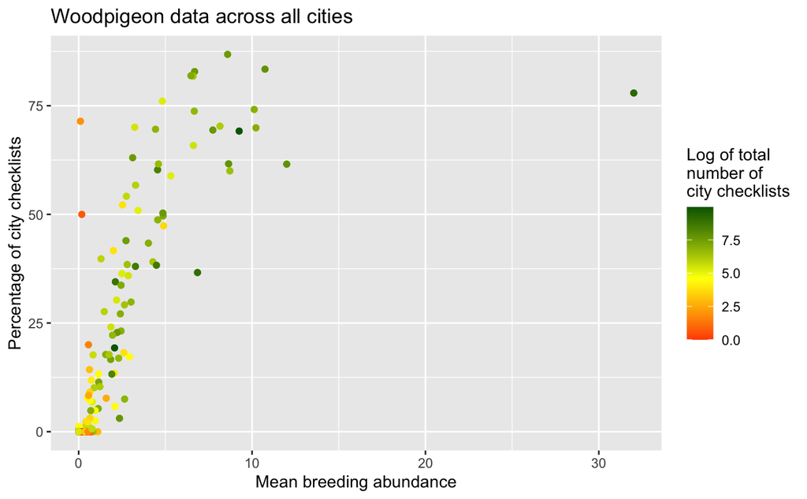

## Breeding abundance

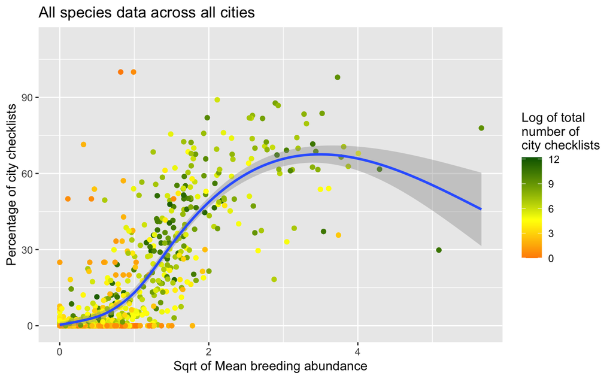

Outliers, where sqrt of breeding abundance greater than 3.5

| city_id | city_name | species_name | total_city_checklists | total_city_effort | seasonal | total_presence_checklists | total_presence_effort | percentage_checklists | percentage_effort | ID | mean_breeding | median_breeding | sd_breeding | mean_nonbreeding | median_nonbreeding | sd_nonbreeding | mean_resident | median_resident | sd_resident | max_mean_abundance |
| --- | --- | --- | --- | --- | --- | --- | --- | --- | --- | --- | --- | --- | --- | --- | --- | --- | --- | --- | --- | --- |
| 65 | Hermosillo | Zenaida asiatica | 1005 | 21788 | Resident | 709 | 16840 | 70.54726 | 77.29025 | 10 | 14.51512 | 14.14597 | 2.079928 | 9.95470433 | 9.25076675 | 2.6485676 | NA | NA | NA | 14.51512 |
| 79 | Phoenix | Zenaida asiatica | 40339 | 1323476 | Breeding Season | 12028 | 429947 | 29.81730 | 32.48620 | 13 | 25.88342 | 26.60539 | 5.060879 | 0.08847874 | 0.04211387 | 0.1090727 | NA | NA | NA | 25.88342 |
| 79 | Phoenix | Zenaida macroura | 40339 | 1323476 | Resident | 24885 | 883749 | 61.68968 | 66.77484 | 13 | 18.41526 | 18.30486 | 4.165674 | 14.82000719 | 15.15989923 | 3.5121038 | NA | NA | NA | 18.41526 |
| 84 | Tucson | Zenaida asiatica | 34527 | 1035100 | NA | 12826 | 439979 | 37.14774 | 42.50594 | 14 | 12.53123 | 12.55770 | 1.750243 | 0.34168020 | 0.26661626 | 0.2140978 | NA | NA | NA | 12.53123 |
| 126 | Torreon | Zenaida asiatica | 98 | 5109 | Resident | 53 | 2902 | 54.08163 | 56.80172 | 23 | 13.02103 | 13.07252 | 2.988627 | 14.89607006 | 15.25844336 | 3.4707100 | NA | NA | NA | 14.89607 |
| 143 | Ciudad Juárez | Zenaida asiatica | 750 | 24984 | Resident | 471 | 17465 | 62.80000 | 69.90474 | 26 | 14.99298 | 14.67890 | 2.759255 | 13.04151517 | 12.55303955 | 2.4444308 | NA | NA | NA | 14.99298 |
| 237 | Reynosa | Zenaida asiatica | 14 | 371 | Breeding Season | 5 | 158 | 35.71429 | 42.58760 | 42 | 13.98713 | 14.00249 | 2.367235 | 2.27828902 | 2.32425547 | 0.4805548 | NA | NA | NA | 13.98713 |
| 1040 | Cordoba | Zenaida auriculata | 4919 | 112006 | Resident | 4117 | 95082 | 83.69587 | 84.89010 | 133 | 12.39501 | 12.21513 | 2.096319 | 14.60175804 | 14.28722334 | 2.9713043 | NA | NA | NA | 14.60176 |
| 1075 | Rosario | Zenaida auriculata | 131 | 5996 | Resident | 89 | 4797 | 67.93893 | 80.00334 | 136 | 16.05245 | 16.14222 | 2.187931 | 17.20333760 | 17.13629913 | 2.9657767 | NA | NA | NA | 17.20334 |
| 1110 | Buenos Aires | Zenaida auriculata | 6719 | 305601 | Resident | 4468 | 223159 | 66.49799 | 73.02299 | 139 | 14.25642 | 13.93040 | 1.945817 | 11.28859113 | 11.14652395 | 1.7436017 | NA | NA | NA | 14.25642 |

[output cut: 2 more lines]

## Resident abundance

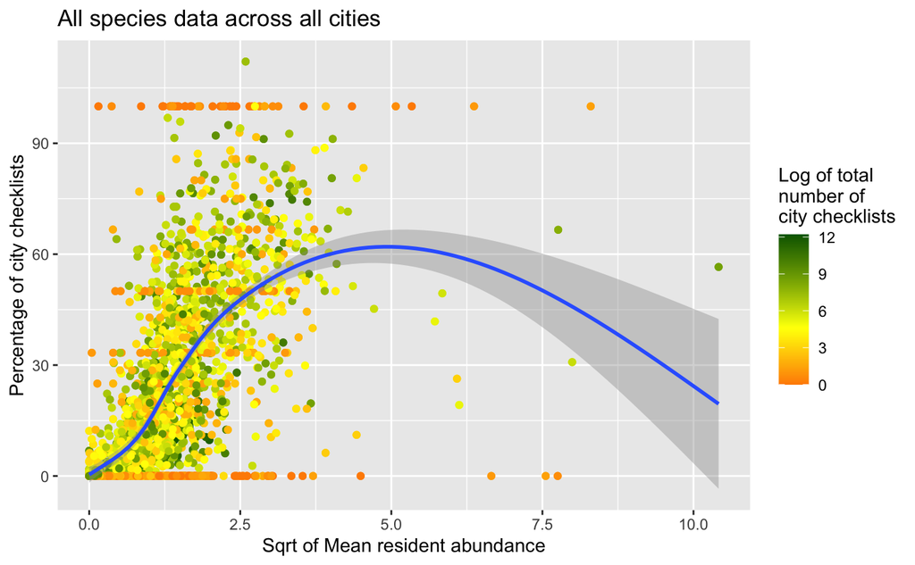

Outliers, where sqrt of resident abundance greater than 5

| city_id | city_name | species_name | total_city_checklists | total_city_effort | seasonal | total_presence_checklists | total_presence_effort | percentage_checklists | percentage_effort | ID | mean_breeding | median_breeding | sd_breeding | mean_nonbreeding | median_nonbreeding | sd_nonbreeding | mean_resident | median_resident | sd_resident | max_mean_abundance |
| --- | --- | --- | --- | --- | --- | --- | --- | --- | --- | --- | --- | --- | --- | --- | --- | --- | --- | --- | --- | --- |
| 3915 | Cairo | Columba livia | 340 | 23664 | Resident | 168 | 10476 | 49.41176 | 44.26978 | 368 | NA | NA | NA | NA | NA | NA | 34.13813 | 31.02329 | 11.463622 | 34.13813 |
| 3927 | Banha | Columba livia | 3 | 99 | Resident | 3 | 99 | 100.00000 | 100.00000 | 369 | NA | NA | NA | NA | NA | NA | 40.56224 | 39.20191 | 10.704402 | 40.56224 |
| 3941 | Mansoura | Columba livia | 4 | 45 | Resident | 0 | 0 | 0.00000 | 0.00000 | 371 | NA | NA | NA | NA | NA | NA | 57.06116 | 58.86131 | 14.094073 | 57.06116 |
| 4089 | Port Said | Columba livia | 19 | 1370 | Resident | 5 | 400 | 26.31579 | 29.19708 | 379 | NA | NA | NA | NA | NA | NA | 37.04611 | 37.41836 | 6.416860 | 37.04611 |
| 4096 | Al Ismailiya | Columba livia | 2 | 120 | Resident | 0 | 0 | 0.00000 | 0.00000 | 381 | NA | NA | NA | NA | NA | NA | 60.10842 | 59.16945 | 14.134138 | 60.10842 |
| 4157 | Suez | Columba livia | 3 | 130 | Resident | 0 | 0 | 0.00000 | 0.00000 | 387 | NA | NA | NA | NA | NA | NA | 44.27538 | 45.82261 | 7.189439 | 44.27538 |
| 4328 | Tel Aviv | Columba livia | 5143 | 148778 | Resident | 2908 | 96188 | 56.54287 | 64.65203 | 402 | NA | NA | NA | NA | NA | NA | 108.48320 | 100.74876 | 30.981980 | 108.48320 |
| 4355 | Beirut | Columba livia | 177 | 7428 | Resident | 34 | 1101 | 19.20904 | 14.82229 | 403 | NA | NA | NA | NA | NA | NA | 37.48885 | 34.75373 | 11.598475 | 37.48885 |
| 4370 | Jerusalem | Columba livia | 2736 | 151302 | Resident | 1822 | 114438 | 66.59357 | 75.63548 | 405 | NA | NA | NA | NA | NA | NA | 60.23125 | 57.28922 | 15.450753 | 60.23125 |
| 4412 | Irbid | Columba livia | 4 | 100 | Resident | 4 | 100 | 100.00000 | 100.00000 | 406 | NA | NA | NA | NA | NA | NA | 68.87963 | 66.44177 | 10.699432 | 68.87963 |

[output cut: 4 more lines]

## Create max_abundance parameter

max_abundance is the maximum of breeding, nonbreeding, or resident abundance.

```r
columbidae$max_mean_abundance = apply(columbidae[,c('mean_breeding', 'mean_nonbreeding', 'mean_resident')], 1, max, na.rm = T)
columbidae$max_mean_abundance[columbidae$max_mean_abundance == -Inf] = NA
```

Plot that against percentage of checklists, remove outliers where sqrt of max_abundance greater than 5.

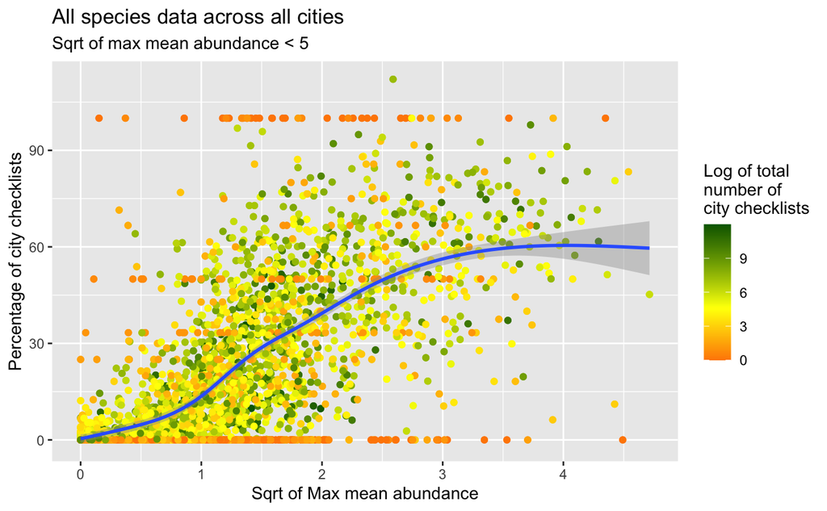

Create trimmed dataset, removing all species with a sqrt of max_abundance greater than 5.

## Test predicting abundance directly.

Here we try to predict abundance from the percentage of checklists a species occurs on. We try to find a cut off for the minimum total number of checklists recorded in a city to improve the prediction. For each test we split the cities 50/50 into training and test data, and run the test 20 times for each cut off.

```r
seeds = c(123, 456, 678, 10, 11, 345, 32, 11, 54, 90, 9999, 1234, 5678, 2323, 9011, 532, 111, 678, 6501, 3)

# min_city_checklists is the minimum number of cities a checklist must have to be included.
# get_model is a function that takes a dataframe subset of `columbidae`, and returns the result of `lm`
# get_actual is a function that returns the expected result of the prediction given a dataframe subset of `columbidae`
get_mean_test_error = function(min_city_checklists, get_model, get_expected) {
  data = trimmed_data[trimmed_data$total_city_checklists >= min_city_checklists,]

  result = data.frame()

  for(seed in seeds) {
    set.seed(seed)
    train = sample(1:nrow(data), nrow(data)/2)
    test=(-train)

    model = get_model(data[train,])
    prediction = predict(model, data[test,])

    result = rbind(result, data.frame(prediction = prediction, actual = get_expected(data[test,])))
  }

  sum((result$prediction - result$actual)^2) / nrow(result)
}

min_city_checklists = seq(0, 5000, by=10)
```

### Predict abundance directly

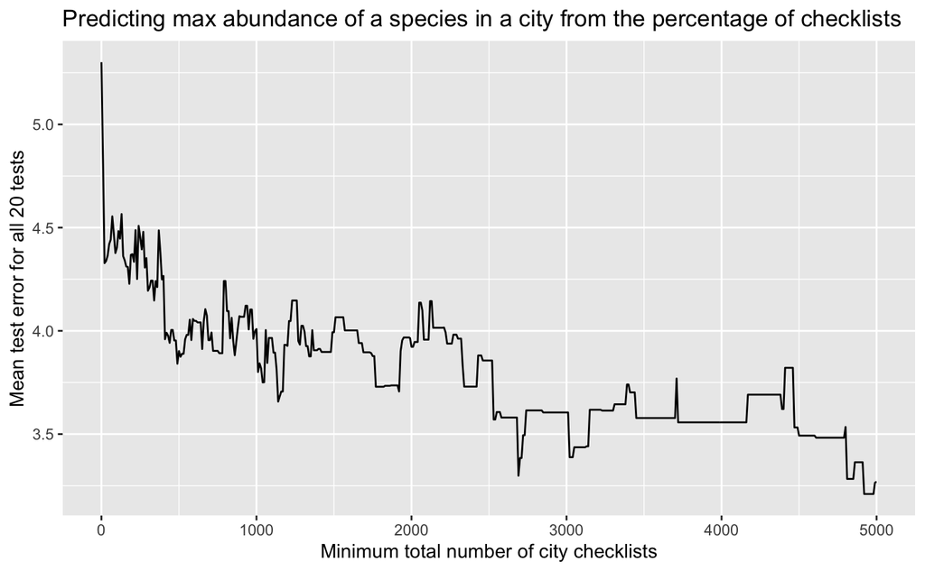

### Predict square root of abundance

Here we repeat the above test, but instead try to predict the sqrt of max abundance.

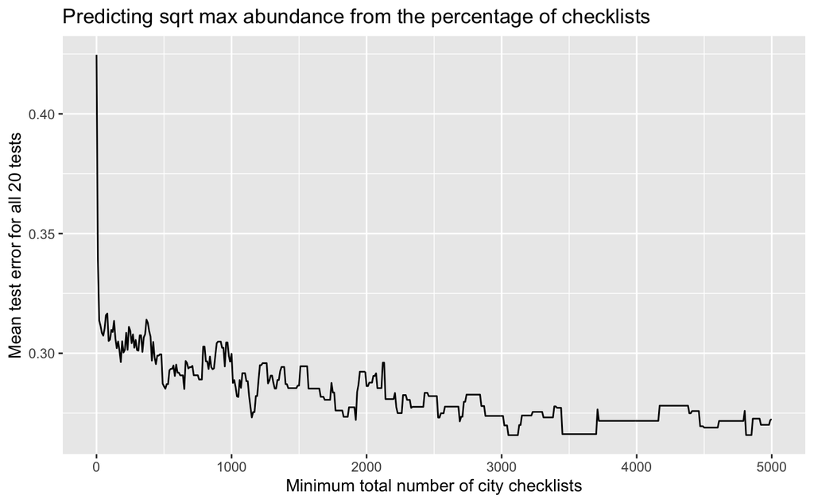

## Test predicting the presence.

Here we try a simpler test of whether a species is present or not. Set present as having whether a species has a max_mean_abundance greater than 0

```r
trimmed_data$nonzero_abundance = trimmed_data$max_mean_abundance > 0
```

Bin data into 25 bins based on number of total city checklists. Boxplot percentage of checklists based on whether species are present (i.e. max_mean_abundance greater than 0)

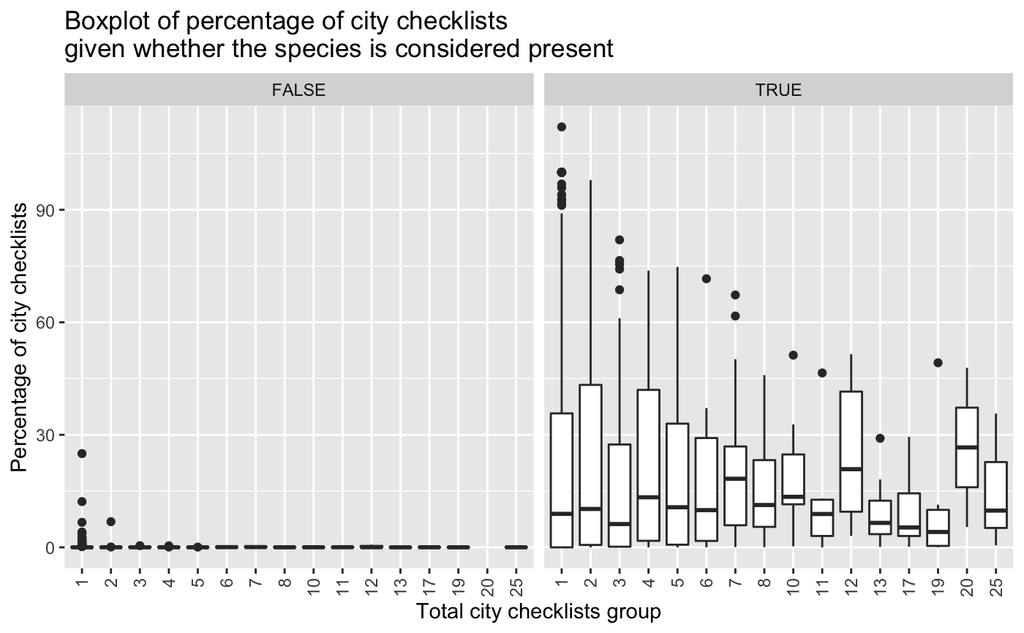

Here we can see that there is a prediction problem with species considered present that have a very low percentage of recorded checklists.

```r
get_true_false_test_results = function(min_city_checklists) {
  data = trimmed_data[trimmed_data$total_city_checklists >= min_city_checklists,]

  result = data.frame()
  coeeffs = c()

  for(seed in seeds) {
    train = sample(1:nrow(data), nrow(data) / 2)
    test=(-train)

    model = glm(nonzero_abundance ~ percentage_checklists, "binomial", data[train,])
    prediction = predict(model, data[test,], type = "response")

    result = rbind(result, data.frame(actual = data$nonzero_abundance[test], predicted = prediction))
    coeeffs = append(coeeffs, model$coefficients['percentage_checklists'])
  }

  data.frame(
    mean_false_probability = mean(result$predicted[!result$actual]),
    mean_true_probablility = mean(result$predicted[result$actual]),
    percentage_checklists_cutoff = mean(coeeffs),
    min_city_checklists = min_city_checklists
  )
}
```

Try predicting species presence (i.e. max_mean_abundance > 0) based on the percentage of checklists a species is recorded on. For each run we predict the result in our test data, and then find the mean prediction for true vs false.

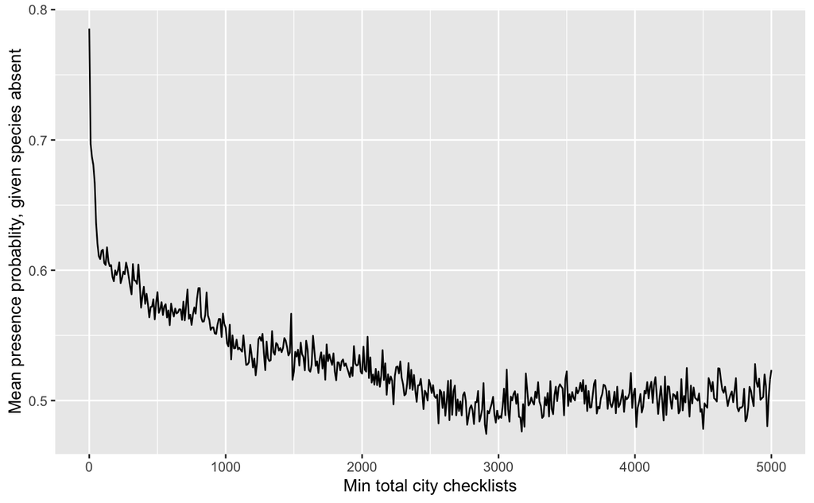

Some results at different minimum total city checklists, the test estimate gives us a percentage of checklists cut off for whether a species is present. However, we can see that the mean probabilty for present remains high for species that are absent.

|  | mean_false_probability | mean_true_probablility | percentage_checklists_cutoff | min_city_checklists |
| --- | --- | --- | --- | --- |
| 11 | 0.6157784 | 0.9237906 | 2.321602 | 100 |
| 51 | 0.5831965 | 0.9146658 | 2.430839 | 500 |
| 101 | 0.5559695 | 0.9028904 | 1.996303 | 1000 |
| 151 | 0.5222456 | 0.8932674 | 2.722900 | 1500 |
| 201 | 0.5206953 | 0.8956956 | 2.535435 | 2000 |

Take a look at those records that are expected present, but have low percentage of checklists recorded. Is there any pattern here?

| city_name | species_name | total_city_checklists | mean_breeding | median_breeding | mean_resident | median_resident | mean_nonbreeding | median_nonbreeding | seasonal | percentage_checklists | city_id |
| --- | --- | --- | --- | --- | --- | --- | --- | --- | --- | --- | --- |
| San Jose | Streptopelia orientalis | 106592 | 0.000000000000 | 0.0000000000 | NA | NA | 0.0003440495171 | 0.000000000000 | NA | 0.161362954 | 10 |
| Los Angeles | Columbina passerina | 121497 | 0.002103069378 | 0.0000000000 | NA | NA | 0.0009214466474 | 0.000000000000 | Resident | 0.036214886 | 14 |
| Los Angeles | Spilopelia chinensis | 121497 | NA | NA | 0.0030912079444 | 0.0000000000 | NA | NA | NA | 0.049383935 | 14 |
| Los Angeles | Zenaida asiatica | 121497 | 0.000070908487 | 0.0000000000 | NA | NA | 0.0000207223899 | 0.000000000000 | Breeding Season | 0.116875314 | 14 |
| Concord | Streptopelia decaocto | 12338 | NA | NA | 0.3246330573283 | 0.2742390633 | NA | NA | Resident | 2.253201491 | 19 |
| Tijuana | Patagioenas fasciata | 65072 | 0.003000820681 | 0.0000000000 | NA | NA | 0.0103148501051 | 0.000000000000 | Resident | 0.010757315 | 21 |
| Tijuana | Zenaida asiatica | 65072 | 0.041113883588 | 0.0000000000 | NA | NA | 0.0012412602780 | 0.000000000000 | Breeding Season | 0.170580280 | 21 |
| Bakersfield | Columbina passerina | 2133 | 0.000575554115 | 0.0000000000 | NA | NA | 0.0008385953700 | 0.000000000000 | Resident | 0.000000000 | 29 |
| Bakersfield | Spilopelia chinensis | 2133 | NA | NA | 0.0102091749198 | 0.0000000000 | NA | NA | NA | 0.421940928 | 29 |
| Sacramento | Patagioenas fasciata | 29631 | 0.000000000000 | 0.0000000000 | NA | NA | 0.0017313635850 | 0.000000000000 | Resident | 0.037123283 | 49 |

[output cut: 489 more lines]